# 2019 Bay Wheels Bike Sharing Data Explonatory Visulaization

## by Rahma Mustafa

## Investigation Overview

> In this investigation, we will describe the bike ride sharing trends and user type of the bay Area bike share system. our goal to know the duration of trips and gender of users and relations between age, gender and duration

## Dataset Overview

> Our data set provides information about the Individual rides that made in a bike-sharing system that covered in the larger San Francisco Bay Area, California. The fisrt Bike share in Bay Area launched in Aguest 2013. Currently this system has more than 2000 bicycles in 262 stations. Ford GoBike system launched on 2017. This data set in 2019 , Febraury

## (Trip Duration (min) )

> The range of duration in first figure was very large so we need to reduce it with log scale to be normall disrubtion like second figure

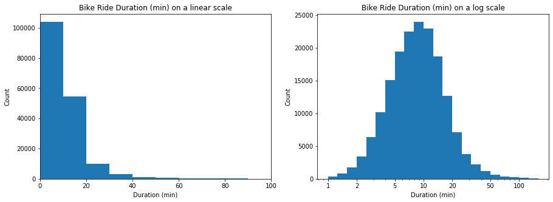

## Members Age

> now we distribute the age of members normally using Log scale. Age range between 20 to 50 years

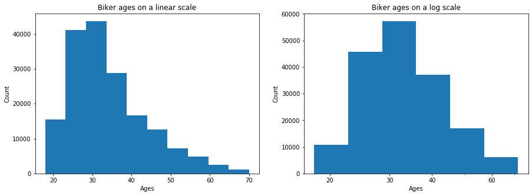

## Day/Hour of weeks and biker type visualization:

> - Male bikers are more than female bikers
> - the customers ride trips in all days in week in the same range, in comprison to subscriber ride in week work days more than weekends
> - During normal rush hours, when people are going to work in the morning and getting off work in the afternoon, subscriber usage visibly surges.Customers who ride in the day did not exhibit a similar pattern.

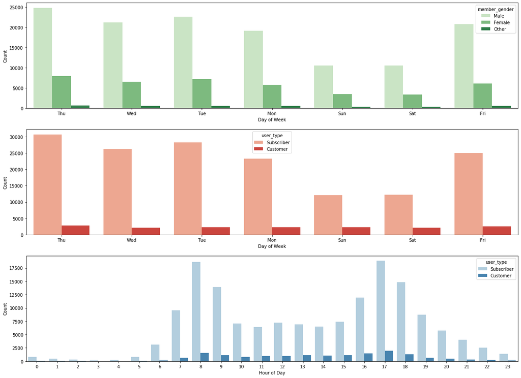

## Duration/Hour trips that use from Males and Females also Customers and Subscribers during weekdays

[figure not shown]